# 脑信号分析中的深度学习方法

作者：刘俊浩，孔令东，何杰，陈浩彬

## 1. 深度学习与脑机接口

深度学习（Deep Learning）这项技术日趋成熟，近几年来已经在视觉、语言及众多AI相关领域取得了突破性的进展。在这个展示中，我们将着重描述深度学习 与脑机接口结合的分析方法，并尝试结合最新的论文实例和代码带来充实的讲解。

### 深度学习方法的趋势

我们统计了**2014-2017年**在生物工程方向的期刊**IEEE Transactions on Biomedical Engineering**上发表的近1500篇论文的情况。从统计数据中我们不难看出，Deep Learning在该领域的介入还相对较少，但随着它的不断发展与成熟，我们相信，越来越多的基于Deep Learning的方法将应用到这个领域并取得很好的应用效果。

[figure not shown]

### 为什么是Deep Learning

[figure not shown]

在基于标签数据的前提下，传统方法用于设计所需的流程如上图所示。在大多数情况下，系统包括三个连续的处理步骤：（1）预处理，（2）特征提取，（3）分类或其他学习。前两个步骤用于建立一个从生理信号中提取和分析信息的系统，这种方法是以目标为导向的，因为设计过程受算法表现的约束.

这其中存在的另一个问题是，没有方法能够告知我们究竟哪一个特征提取算法是最适合于给定问题的。特征质量只能用统计学方法建立，有两个原因造成了这种情况难以令人满意。**第一个原因**是在选择性能最好的特征提取方法之前，必须对生理信号进行各种特征提取算法评估，但即使增加了的这样一种操作也不能确保我们能够提取到最相关的信息。**第二个原因**来自于这样一个事实，即只有少量的特征被用于决策，因为对于高维输入，决策算法的性能将会恶化。因此，当前决策支持系统的主要设计目标是限制支持决策的信息量。

目前的决策系统对大型和变化的数据集表现欠佳，因为它们不能处理足够多样化以覆盖所有场景的信息。需要更多的深度来表示数据集中的所有信息。从根本上说，我们需要隐含的知识，以便根据从生理信号中提取的信息做出好的决策。而在过去，隐含的知识只有经过专业训练的医生才能得出。

在这样一种背景下，我们引入深度学习的方法，用以克服需要考虑训练数据集提供的所有信息而造成信息难以被处理的缺点。该方法能够在机器中建立隐性知识。

## 2. EEG analysis based on deep Learning

以下将从神经网络的基本组成部件出发，对每一个部件的应用进行介绍，包括：

```
1. 全连接网络
2. 卷积神经网络
3. 循环神经网络
4. 生成对抗网络
```

### 2.1 Fully Connected Neural Network(FC)

#### 神经元

[figure not shown]

#### 全连接层

[figure not shown]

#### 激活函数

除了我们熟悉的Sigmoid激活函数外，还有很多目前应用广泛的非线性激活函数，如：ReLU、SELU等等（它们的函数曲线见下图）。

[figure not shown]

#### 现今常用的FC

[figure not shown]

- **Softmax** 离散的概率分布$$\text{Softmax}(x_{i}) = \frac{exp(x_i)}{\sum_j exp(x_j)}$$

[figure not shown]

- **ReLU** 有效避免梯度弥散的激活函数$$\text{ReLU}(x) = \max(0, x)$$

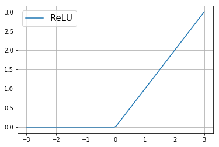

```python
plt.plot(value.numpy(), ReLU(value).numpy(), label='ReLU')
plt.grid(True)
plt.legend(fontsize=15)
plt.show()
```

#### FC的输入和输出可以是什么？

- **图像的输入**

[figure not shown]

- **目标的输出（以分类为例）** 使用one-hot encoding作为目标的标签。

### 2.1 Convolutional Neural Network(CNN)

#### 卷积操作

- **filter**

[figure not shown]

- **卷积过程**

[figure not shown]

- **padding**

[figure not shown]

(source:[CNNs from different viewpoints](https://medium.com/impactai/cnns-from-different-viewpoints-fab7f52d159c))

- **pooling**

[figure not shown]

(source:[Convolutional Neural Networks (CNNs / ConvNets)](http://cs231n.github.io/convolutional-networks/))

- **Typical CNN architecture**

[figure not shown]

#### 一个比较有代表性的例子：EEGNet

[figure not shown]

(source:[EEGNet: A Compact Convolutional Neural Network for EEG-based Brain-Computer Interfaces](https://arxiv.org/pdf/1611.08024.pdf))

过去有关将CNN应用于BCI的工作大都只能适用于一种范式，本篇论文提出了一种适用于EEG信号分析的袖珍卷积神经网络。实验表明，它在四种BCI范式，P300 visual-evoked potentials, error-related negativity responses (ERN), movement-related cortical potentials (MRCP), and sensory motor rhythms (SMR)上较以往的方法都取得了最为优秀的结果。

([源代码](https://github.com/vlawhern/arl-eegmodels))

CNN在处理脑信号时，通常需要处理两种信息：

1. 空间信息
2. 时间信息

在面对这两个问题时，目前常用的方法是这样的，通过利用CNN的特性构造spatial filter与temporal filter。

针对我们采集到的数据，可以表示成这种形式。

[figure not shown]

构建spatial filter与temporal filter常见的方式如下：

[figure not shown]

因此，一个利用CNN进行脑信号分析的模型一般都有如下架构。

[figure not shown]

基于前面描述的想法，EEGNet提出了以下的模型，包含了普通的卷积操作、Depthwise convolution及Separable Convolution。

[figure not shown]

- **与以往的模型相比EEGNet有什么优势？**

首先，我们需要对比一下传统的卷积与其他两种卷积的区别。

[figure not shown]

```python
# 计算比较
W = 3
H = 3
ID = 3
OD = 128
DM = 4

tp_conv = W*H*ID*OD
sep_conv = W*H*ID*DM + ID*DM*OD

print('Typical Convolition:', tp_conv,'\nSeparable Conolution:', sep_conv)
```

```
Typical Convolition: 3456
Separable Conolution: 1644
```

- **模型的具体设计**

[figure not shown]

**1. Conv2D:** 设定kernel(filter)的大小为(1, 64)，64在这里为信号采样频率的一半，在论文中使用的采样频率为128Hz。这一步的处理是为了提取时间上的信息，进而提取出不同的带通频率，其中它最低能够允许通过2Hz的信号。

**2. Depthwise2D:** 使用Depthwise2D进而实现空间信息的提取，这个方法在计算机视觉领域，近来被广泛使用。在BCI信号分析中，可以针对任务的复杂度自由地设置这一层的参数（上图为使用深度为1的结果）。这样设计的好处是为了能够针对前面产生的不同频率的特征图，自如地学习出对应的空间滤波器。

[figure not shown]

**3. SeqarableConv2D:** 在经过前面的处理之后的信号，经过均值池化，可以将信号的频率降低为32Hz。通过设定SeqarableConv2D的kernel为(1, 16)可以对长度为500ms的32Hz信号进行时间上的分析。这一步能够使得针对不同频率的信号再次结合起来做最后的分类学习

- **Experimental Results**

[figure not shown]

### 2.2 Recurrent Neural Network(RNN)

- **An unrolled recurrent neural network**

可以根据时间顺序进行建模。

[figure not shown]

- **LSTM(Long short-term memory networks)**

LSTM是一种特殊的RNN结构，他可以解决传统RNN所不能解决的learning long-term dependencies的问题，这与它的结构是密切相关的。

[figure not shown]

LSTM存在三个门来控制记忆信息的流动，可以更好地处理长序列的问题，有关更细节的内容可以参看相关参考文献。

- **A slightly more dramatic variation on the LSTM is the Gated Recurrent Unit(GRU)**

[figure not shown]

(source:[Understanding LSTM Networks](http://colah.github.io/posts/2015-08-Understanding-LSTMs/))

### 2.3 Multi-modal Learning

结合前面所说的CNN与LSTM网络，我们可以尝试结合两种的处理模型来对我们的脑信号进行分析，下面我们给出一个参考的例子。

[figure not shown]

(source:[Cascade and Parallel Convolutional Recurrent Neural Networks on EEG-Based Intention Recognition for Brain Computer Interface](https://www.aaai.org/ocs/index.php/AAAI/AAAI18/paper/viewPaper/16107))

本文是基于运动想象任务来讨论作者提出的方法的。运动想象，作为脑信号分析任务的一种，目的是为了能够在被试者不做出实际动作的情况下识别出它的运动意图。作者针对此任务提出了两种网络架构：**平行及级联的架构**，并且指出以往在预处理序列信号时的不足，提出了一种新的预处理方式。实验表明，作者提出的网络架构在同一个被试者上能够**取得98.3%的准确率**；在跨被试者的情况下较以往工作也取得了18%的准确率的提升。

- **EEG data acquistion and preprocessing**

[figure not shown]

上图描述了信号采集及论文提出的预处理的过程，值得注意的地方有两点。

1. **将时间序列信号转换为包含空间信息的矩阵**

[figure not shown]

1. **使用滑动窗口(sliding window)的方法进行时间信息上的分析**

   根据信号的采样率及脑活动的信号特点选择窗口大小与滑动间隔对原始信号进行分割。

[figure not shown]

([实验数据](https://github.com/pbashivan/EEGLearn))

- **Cascade Convolutional Recurrent Network**

[figure not shown]

- **Parallel Convolutional Recurrent Network**

[figure not shown]

- **Experimental Results**

[figure not shown]

### 2.4 Generative Adversarial Network(GAN)

生成对抗网络是一种新兴的半监督和无监督学习的技术，这种方法主要是通过隐式地对高维数据分布进行建模来实现这一点。对抗生成网络首次是在2014年被提出，他的主要特点是可以通过对抗竞争训练的形式得到一对的网络。

第一网络，**分类器**，被训练来区分真假输入数据。第二网络，即**生成器**，以潜在噪声变量z作为输入，并尝试生成识别器不识别为伪的伪样本。

[figure not shown]

在基本的对抗生成网络中，分类器网络D可以类似地描述为从图像数据映射到图像来自真实数据分布的概率，而不是生成器分布。对于固定的生成器，分类器可以被训练来进行图像分类，分开来自训练数据的图片（真实的，接近于一个）和自固定的生成器产生的伪造图片（假的，接近于零）。当鉴别器达到最佳的时候，它可以将会停止训练。同时，生成器G可以继续训练以降低鉴别器的精度。如果生成器分布能够完全匹配实际的数据分布，则判别器将被最大程度地混淆，预测所有输入的属于真实数据的几率为0.5。

[figure not shown]

- **GAN 结构**
  1. 全链接GANs
  2. 卷积GANs
  3. 条件GANs
  4. GANs 推理模型
  5. 对抗自编码器
- **GANs 训练**
  1. 调整参数 使得分类器网络分类正确率最高
  2. 调整参数 使得生成器网络的输出能最大程度接近样本分布，即能在最大程度上混淆分类器。

基本思路：固定一个模型的参数，更新其中一个模型的参数。

[figure not shown]

(source: [Generative Adversarial Networks: An Overview](http://cn.arxiv.org/pdf/1710.07035))

#### EEG-GAN: Generative adversarial networks for electroencephalograhic (EEG) brain signals

[figure not shown]

(source:[EEG-GAN: Generative adversarial networks for electroencephalograhic (EEG) brain signals](http://cn.arxiv.org/pdf/1806.01875.pdf))

由于生成对抗网络（GAN）在图像的生成应用中非常成功，并开始应用于时间序列数据。这篇文章描述EEG-GAN一个框架，以产生脑电图（EEG）脑信号。通过一种改进WGAN训练方法，能够逐步训练GAN以稳定方式产生在时域和频域上与单通道真实EEG信号非常相似的人工EEG信号。在神经科学领域开辟了新的生成性应用。这个EEG-GAN可以应用于脑机接口任务中的实验数据扩充、脑电超采样或损坏数据段的恢复。并且EEG-GAN也为产生特定类别和/或具有特定性质的信号提供了可能性，同时也有助于深入的研究脑信号的潜在结构。

## 3. Demo

Kaggle比赛简介。